# Olas de calor y muerte en España

FUENTES DE DATOS BIOMÉDICOS

Laura Lasierra Gastón, Ángela Navarro Cantón y Sergio Pascual Redondo

2026-11-23

## Paquetes necesarios

Antes de ejecutar el proyecto por primera vez, es necesario instalar los siguientes paquetes de R:

```r
install.packages(c("tidyverse","jsonlite","tidyjson","pxR","mapSpain","plotly"))
```

Importamos los datos (.json) correspondientes a las muertes ocurridas en 2020 (aumento en 2020 frente 2019) en las distintas comunidades autónomas y de las olas de calor por provincia. También importamos el archivo csv correspondiente a las muertes por covid en ese mismo año y los datos de población (INE) de 2020 en formato PC-Axis.

Definimos la función leer_json para que R ignore el carácter invisible (BOM) con el que empieza nuestro archivo JSON.

```r
leer_json <- function(ruta) {
  paste(readLines(file(ruta, encoding = "UTF-8-BOM"), warn = FALSE),
    collapse = "\n")

}
```

### Aumento de muertes en 2020 respecto a 2019 por comunidad autónoma

Nuestro json de muertes en 2020 por CCAA está anidado, así que para poder imporar los datos que nos interesan lo hacemos de la siguiente manera:

```r
muertes_json <- leer_json("INPUT/DATA/muertes_comunidad_autonoma_2020.json")


muertes_json %>%
  spread_all()%>%
  gather_object() %>%
  json_types() %>%
  dplyr::count (name, type)
```

| name | type | n |
| --- | --- | --- |
| Respuesta | object | 1 |
| Url | string | 1 |

```r
#entramos capa a capa hasta la tabla de datos y la aplanamos
muertes <- muertes_json %>%
  enter_object ("Respuesta")%>%
  enter_object("Datos") %>%
  enter_object ("Metricas")%>%
  gather_array() %>%
  enter_object("Datos")%>%
  gather_array(column.name = "indice_ccaa") %>%
  spread_all() %>%
  as_tibble() %>%
  select (ano= Agno, ccaa=Parametro, var_defunciones= Valor, estado=Estado)

muertes
```

| ano | ccaa | var_defunciones | estado |
| --- | --- | --- | --- |
| 2020 | País Vasco | 2806 | Definitivo |
| 2020 | Murcia | 984 | Definitivo |
| 2020 | Navarra | 1267 | Definitivo |
| 2020 | Comunidad Valenciana | 5762 | Definitivo |
| 2020 | La Rioja | 633 | Definitivo |
| 2020 | Ceuta | 114 | Definitivo |
| 2020 | Melilla | 97 | Definitivo |
| 2020 | Madrid | 19584 | Definitivo |
| 2020 | Galicia | 1929 | Definitivo |
| 2020 | Extremadura | 1784 | Definitivo |

[output cut: 9 more lines]

### Olas de calor por provincia

```r
olas_json <- leer_json("INPUT/DATA/olas_calor_provincias_2020.json")

olas_json %>%
  spread_all()%>%
  gather_object() %>%
  json_types () %>%
  dplyr::count (name, type)   #datos sigue siendo un array
```

| name | type | n |
| --- | --- | --- |
| datos | array | 1 |
| fuente | string | 1 |
| nota | string | 1 |

```r
olas <- olas_json %>%
  enter_object("datos")%>%
  gather_array() %>%
  spread_all()%>%
  as_tibble()%>%
  select(-document.id, -array.index) %>% #eliminamos estas dos columnas que aparecen por defecto

  mutate(across(c(fecha_inicio, fecha_fin), as.Date), #guardamos las fechas en formato Date
  duracion_dias = as.integer(fecha_fin - fecha_inicio) +1)  #calculamos cuantos días duró cada ola de calor, dato que utilizaremos más adelante.

olas
```

| anio | id_ola | fecha_inicio | fecha_fin | provincia | numero_provincias_ola | duracion_dias |
| --- | --- | --- | --- | --- | --- | --- |
| 2020 | 1 | 2020-07-18 | 2020-07-20 | ALMERIA | 11 | 3 |
| 2020 | 1 | 2020-07-18 | 2020-07-20 | CADIZ | 11 | 3 |
| 2020 | 1 | 2020-07-18 | 2020-07-20 | CUENCA | 11 | 3 |
| 2020 | 1 | 2020-07-18 | 2020-07-20 | JAEN | 11 | 3 |
| 2020 | 1 | 2020-07-18 | 2020-07-20 | LEON | 11 | 3 |
| 2020 | 1 | 2020-07-18 | 2020-07-20 | MADRID | 11 | 3 |
| 2020 | 1 | 2020-07-18 | 2020-07-20 | MALAGA | 11 | 3 |
| 2020 | 1 | 2020-07-18 | 2020-07-20 | OURENSE | 11 | 3 |
| 2020 | 1 | 2020-07-18 | 2020-07-20 | SEGOVIA | 11 | 3 |
| 2020 | 1 | 2020-07-18 | 2020-07-20 | SORIA | 11 | 3 |

[output cut: 51 more lines]

### Muertes por COVID en 2020

Datos del INE en formato CSV (separado por punto y coma y codificado en latin1).

```r
covid_csv <- read_delim("INPUT/DATA/49923.csv",
                        delim = ";",
                        escape_double = FALSE,
                        trim_ws = TRUE,
                        locale = locale(encoding = "latin1", decimal_mark=",", grouping_mark="."),
                        col_types = cols(Total = col_number()))

covid <- covid_csv %>%
  rename (ccaa_raw=2, muertes_covid = Total)%>%
  filter(!is.na(ccaa_raw)) %>%
  mutate(ccaa = str_remove(ccaa_raw, "^\\d+\\s+"),
         ccaa= case_match(ccaa,
           "Asturias, Principado de"      ~ "Asturias",
           "Balears, Illes"               ~ "Islas Baleares",
           "Castilla - La Mancha"         ~ "Castilla-La Mancha",
           "Comunitat Valenciana"         ~ "Comunidad Valenciana",
           "Madrid, Comunidad de"         ~ "Madrid",
           "Murcia, Región de"            ~ "Murcia",
           "Navarra, Comunidad Foral de"  ~ "Navarra",
           "Rioja, La"                    ~ "La Rioja",
           .default = ccaa)) %>%
  select(ccaa, muertes_covid)


covid
```

| ccaa | muertes_covid |
| --- | --- |
| Andalucía | 5815 |
| Aragón | 2627 |
| Asturias | 1509 |
| Islas Baleares | 565 |
| Canarias | 396 |
| Cantabria | 428 |
| Castilla y León | 5715 |
| Castilla-La Mancha | 4652 |
| Cataluña | 12898 |
| Comunidad Valenciana | 3138 |

[output cut: 9 more lines]

### Defunciones semanales por comunidad autónoma en 2020

Los datos proceden de la Estimación del número de defunciones semanales del Instituto Nacional de Estadística. El archivo contiene las defunciones registradas durante cada semana de 2020 y 2019 para todas las comunidades autónomas.

```r
muertes_semana_json <- leer_json("INPUT/DATA/defunciones_semana_2020_2019.json")

muertes_semana_json %>%
  gather_array() %>%
  gather_object() %>%
  json_types() %>%
  dplyr::count(name, type) #Data y metaData son array
```

| name | type | n |
| --- | --- | --- |
| COD | string | 21 |
| Data | array | 21 |
| MetaData | array | 21 |
| Nombre | string | 21 |
| T3_Escala | string | 21 |
| T3_Unidad | string | 21 |

```r
muertes_sem <- muertes_semana_json%>%
  gather_array(column.name = "indice_serie")%>%
  spread_values(nombre = jstring("Nombre"))%>%

  enter_object("Data")%>%
  gather_array(column.name = "indice_semana")%>%
  spread_values(fecha=jstring("Fecha"),
                periodo = jstring("T3_Periodo"),
                anyo=jnumber("Anyo"),
                muertes_totales=jnumber("Valor"))%>%

  as_tibble()%>%

  transmute(ccaa_raw = str_remove(nombre, "\\. Total\\..*$"),
            anyo = as.integer(anyo),
            semana = as.integer(str_extract(periodo, "\\d+$")),
            fecha = as.Date(substr(fecha, 1, 10)),
            muertes_totales)


renombrar_ccaa <- function(x) {
  x <- str_remove(x, "^\\d+\\s+")
  case_match(x,
    "Asturias, Principado de"     ~ "Asturias",
    "Balears, Illes"              ~ "Islas Baleares",
    "Castilla - La Mancha"        ~ "Castilla-La Mancha",
    "Comunitat Valenciana"        ~ "Comunidad Valenciana",
    "Madrid, Comunidad de"        ~ "Madrid",
    "Murcia, Región de"           ~ "Murcia",
    "Navarra, Comunidad Foral de" ~ "Navarra",
    "Rioja, La"                   ~ "La Rioja",
    .default = x)
}

muertes_sem <- muertes_sem %>%
  filter(!ccaa_raw %in% c("Total Nacional", "No residente")) %>%
  mutate(ccaa = renombrar_ccaa(ccaa_raw)) %>%
  select(ccaa, semana, fecha, muertes_totales, anyo)

muertes_sem
```

| ccaa | semana | fecha | muertes_totales | anyo |
| --- | --- | --- | --- | --- |
| Andalucía | 53 | 2020-12-31 | 1596 | 2020 |
| Andalucía | 52 | 2020-12-24 | 1557 | 2020 |
| Andalucía | 51 | 2020-12-17 | 1604 | 2020 |
| Andalucía | 50 | 2020-12-10 | 1578 | 2020 |
| Andalucía | 49 | 2020-12-03 | 1703 | 2020 |
| Andalucía | 48 | 2020-11-26 | 1691 | 2020 |
| Andalucía | 47 | 2020-11-19 | 1797 | 2020 |
| Andalucía | 46 | 2020-11-12 | 1913 | 2020 |
| Andalucía | 45 | 2020-11-05 | 1899 | 2020 |
| Andalucía | 44 | 2020-10-29 | 1764 | 2020 |

[output cut: 1985 more lines]

Calculamos la variación de muerte semanal en 2020 frente 2019

```r
tabla_semanal <- muertes_sem %>%
  pivot_wider(id_cols = c(ccaa, semana),
              names_from = anyo,
              values_from = c(fecha, muertes_totales)) %>%

  filter(!is.na(fecha_2019)) %>%
  transmute(ccaa, semana,
            fecha_2019, fecha_2020,
            muertes_2019 = muertes_totales_2019,
            muertes_2020 = muertes_totales_2020,
            variacion_def_semanal = muertes_2020 - muertes_2019)

tabla_semanal
```

| ccaa | semana | fecha_2019 | fecha_2020 | muertes_2019 | muertes_2020 | variacion_def_semanal |
| --- | --- | --- | --- | --- | --- | --- |
| Andalucía | 52 | 2019-12-26 | 2020-12-24 | 1503 | 1557 | 54 |
| Andalucía | 51 | 2019-12-19 | 2020-12-17 | 1451 | 1604 | 153 |
| Andalucía | 50 | 2019-12-12 | 2020-12-10 | 1421 | 1578 | 157 |
| Andalucía | 49 | 2019-12-05 | 2020-12-03 | 1342 | 1703 | 361 |
| Andalucía | 48 | 2019-11-28 | 2020-11-26 | 1411 | 1691 | 280 |
| Andalucía | 47 | 2019-11-21 | 2020-11-19 | 1440 | 1797 | 357 |
| Andalucía | 46 | 2019-11-14 | 2020-11-12 | 1328 | 1913 | 585 |
| Andalucía | 45 | 2019-11-07 | 2020-11-05 | 1305 | 1899 | 594 |
| Andalucía | 44 | 2019-10-31 | 2020-10-29 | 1349 | 1764 | 415 |
| Andalucía | 43 | 2019-10-24 | 2020-10-22 | 1266 | 1708 | 442 |

[output cut: 978 more lines]

### Poblaciones España 1997-2021

Datos del INE en formato pc.Axis.

```r
poblacion_px <- pxR::read.px(
  "INPUT/DATA/poblacion.px"
)

poblacion<- poblacion_px %>%
  as.data.frame(stringsAsFactors = FALSE) %>%
  as_tibble()

poblacion
```

| Periodo | Sexo | Comunidades.y.Ciudades.Autónomas | value |
| --- | --- | --- | --- |
| 2021 | Total | Total | 47385107 |
| 2020 | Total | Total | 47450795 |
| 2019 | Total | Total | 47026208 |
| 2018 | Total | Total | 46722980 |
| 2017 | Total | Total | 46572132 |
| 2016 | Total | Total | 46557008 |
| 2015 | Total | Total | 46624382 |
| 2014 | Total | Total | 46771341 |
| 2013 | Total | Total | 47129783 |
| 2012 | Total | Total | 47265321 |

[output cut: 1550 more lines]

### Defunciones por COVID semanal (csv tabulado)

```r
covid_semanal <- read_delim("INPUT/DATA/muertesCovidSemana.csv",
                            delim="\t",
                            escape_double = FALSE,
                            trim_ws = TRUE,
                            locale = locale(encoding = "latin1"))%>%

  transmute(ccaa= renombrar_ccaa(`Comunidad y ciudad autónoma de defunción`),
            semana = as.integer(str_extract(`Semana de defunción`, "\\d+$")),
            muertes_covid = as.integer(replace_na(
              parse_number(as.character(Total),
                                         na = c("", "NA", "..")),0)))

covid_semanal
```

| ccaa | semana | muertes_covid |
| --- | --- | --- |
| Andalucía | 1 | 0 |
| Andalucía | 2 | 0 |
| Andalucía | 3 | 0 |
| Andalucía | 4 | 0 |
| Andalucía | 5 | 0 |
| Andalucía | 6 | 0 |
| Andalucía | 7 | 0 |
| Andalucía | 8 | 0 |
| Andalucía | 9 | 0 |
| Andalucía | 10 | 0 |

[output cut: 997 more lines]

## Preparación de los datos

### Preparación de la población de 2020

Seleccionamos la población total de cada comunidad autónoma en 2020. Después, homogeneizamos sus nombres con los utilizados en las demás fuentes de datos.

```r
poblacion_2020 <- poblacion %>%
  rename(
    ccaa_raw = `Comunidades.y.Ciudades.Autónomas`
  ) %>%
  filter(
    Periodo == "2020",
    Sexo == "Total",
    ccaa_raw != "Total"
  ) %>%
  transmute(
    ccaa = case_when(
      ccaa_raw == "01 Andalucía" ~ "Andalucía",
      ccaa_raw == "02 Aragón" ~ "Aragón",
      ccaa_raw == "03 Asturias, Principado de" ~ "Asturias",
      ccaa_raw == "04 Balears, Illes" ~ "Islas Baleares",
      ccaa_raw == "05 Canarias" ~ "Canarias",
      ccaa_raw == "06 Cantabria" ~ "Cantabria",
      ccaa_raw == "07 Castilla y León" ~ "Castilla y León",
      ccaa_raw == "08 Castilla - La Mancha" ~ "Castilla-La Mancha",
      ccaa_raw == "09 Cataluña" ~ "Cataluña",
      ccaa_raw == "10 Comunitat Valenciana" ~ "Comunidad Valenciana",
      ccaa_raw == "11 Extremadura" ~ "Extremadura",
      ccaa_raw == "12 Galicia" ~ "Galicia",
      ccaa_raw == "13 Madrid, Comunidad de" ~ "Madrid",
      ccaa_raw == "14 Murcia, Región de" ~ "Murcia",
      ccaa_raw == "15 Navarra, Comunidad Foral de" ~ "Navarra",
      ccaa_raw == "16 País Vasco" ~ "País Vasco",
      ccaa_raw == "17 Rioja, La" ~ "La Rioja",
      ccaa_raw == "18 Ceuta" ~ "Ceuta",
      ccaa_raw == "19 Melilla" ~ "Melilla",
      .default = ccaa_raw
    ),
    poblacion = value
  )

poblacion_2020
```

| ccaa | poblacion |
| --- | --- |
| Andalucía | 8464411 |
| Aragón | 1329391 |
| Asturias | 1018784 |
| Islas Baleares | 1171543 |
| Canarias | 2175952 |
| Cantabria | 582905 |
| Castilla y León | 2394918 |
| Castilla-La Mancha | 2045221 |
| Cataluña | 7780479 |
| Comunidad Valenciana | 5057353 |

[output cut: 9 more lines]

### Cambio de provincias a comunidades autónomas

Nuestros datos de olas de calor vienen por provincia y las defunciones del INE (covid), al igual que las defunciones totales en 2020 por comunidad autónoma. Para poder relacionarlas, asignamos cada provincia a su comunidad autónoma y agrupamos las olas.

```r
prov_ccaa <- enframe(list(
  "Andalucía" = c("ALMERIA","CADIZ","CORDOBA","GRANADA","HUELVA","JAEN","MALAGA","SEVILLA"),
  "Aragón" = c("HUESCA","TERUEL","ZARAGOZA"),
  "Asturias" = "ASTURIAS",
  "Islas Baleares" = "BALEARES",
  "Canarias" = c("LAS PALMAS","SANTA CRUZ DE TENERIFE"),
  "Cantabria" = "CANTABRIA",
  "Castilla y León" = c("AVILA","BURGOS","LEON","PALENCIA","SALAMANCA",
                        "SEGOVIA","SORIA","VALLADOLID","ZAMORA"),
  "Castilla-La Mancha" = c("ALBACETE","CIUDAD REAL","CUENCA","GUADALAJARA","TOLEDO"),
  "Cataluña" = c("BARCELONA","GIRONA","LLEIDA","TARRAGONA"),
  "Comunidad Valenciana" = c("ALICANTE","CASTELLON","VALENCIA"),
  "Extremadura" = c("BADAJOZ","CACERES"),
  "Galicia" = c("A CORUÑA","LUGO","OURENSE","PONTEVEDRA"),
  "La Rioja" = "LA RIOJA",
  "Madrid" = "MADRID",
  "Murcia" = "MURCIA",
  "Navarra" = "NAVARRA",
  "País Vasco" = c("ARABA/ALAVA","BIZKAIA","GIPUZKOA"),
  "Ceuta" = "CEUTA",
  "Melilla" = "MELILLA"

), name = "ccaa", value = "provincia") %>%
  unnest(provincia)

#Comprobamos que ninguna provincia del JSON de olas de calor se quede sin comunidad autonoma
anti_join(olas, prov_ccaa, by = "provincia")
```

| anio | id_ola | fecha_inicio | fecha_fin | provincia | numero_provincias_ola | duracion_dias |
| --- | --- | --- | --- | --- | --- | --- |

```r
olas_prov <- prov_ccaa %>%
  left_join(olas %>%
              group_by(provincia) %>% #agrupamos las olas por provincia
              summarise(n_olas = n_distinct(id_ola), #contamos cuantas olas distintas afectaron a cada provincia
                        dias_ola = sum(duracion_dias), .groups = "drop"), #sumamos los días que duro cada ola
            by = "provincia") %>%
  mutate(across(c(n_olas, dias_ola), ~ replace_na(.x, 0))) #cambiamos los NA por 0 para las provincias sin ola de calor.

olas_ccaa <- olas_prov %>%
  group_by(ccaa) %>% #agrupamos las provincias por comunidad
  summarise(n_provincias = n(), #nº de provincias por cada ccaa
            prov_afectadas_ola = sum(n_olas > 0),
            n_olas_media = mean(n_olas),
            dias_ola_media = mean(dias_ola), .groups = "drop") #calculamos la media de olas y de dias de ola entre las provincias de la comunidad

olas_ccaa
```

| ccaa | n_provincias | prov_afectadas_ola | n_olas_media | dias_ola_media |
| --- | --- | --- | --- | --- |
| Andalucía | 8 | 5 | 1.7500000 | 10.87500 |
| Aragón | 3 | 3 | 1.0000000 | 6.00000 |
| Asturias | 1 | 0 | 0.0000000 | 0.00000 |
| Canarias | 2 | 0 | 0.0000000 | 0.00000 |
| Cantabria | 1 | 0 | 0.0000000 | 0.00000 |
| Castilla y León | 9 | 9 | 1.7777778 | 11.33333 |
| Castilla-La Mancha | 5 | 5 | 2.2000000 | 15.00000 |
| Cataluña | 4 | 4 | 1.7500000 | 13.50000 |
| Ceuta | 1 | 0 | 0.0000000 | 0.00000 |
| Comunidad Valenciana | 3 | 1 | 0.3333333 | 3.00000 |

[output cut: 9 more lines]

### Unión de los datos

Unimos las tablas mediante `ccaa`, una clave común previamente homogeneizada. Como cada tabla contiene una única fila por comunidad autónoma, las uniones presentan cardinalidad **uno a uno**. Utilizamos `left_join()` para conservar todas las comunidades de la tabla principal de defunciones y detectar posibles ausencias mediante valores `NA`.

Finalmente, restamos las defunciones atribuidas oficialmente al COVID-19 al aumento total de defunciones y ajustamos el resultado por cada 100.000 habitantes.

```r
datos_unidos <- muertes %>%
  select(ccaa, var_defunciones) %>%
  left_join(covid, by = "ccaa") %>%
  left_join(olas_ccaa, by = "ccaa") %>%
  left_join(poblacion_2020, by = "ccaa") %>% #añadimos la población de cada comunidad autónoma
  mutate(
    diferencia_muertes_NoCovd = var_defunciones - muertes_covid, #diferencia entre el aumento de defunciones respecto a 2019 en 2020 y las muertes atribuidas al COVID-19 (refleja el cambio neto, con respecto de 2019, en el resto de causas de muertes)
    defunciones_no_covid_100000 = diferencia_muertes_NoCovd / poblacion * 100000 #ajustamos la diferencia por el tamaño de la población y la expresamos por cada 100.000 habitantes
  )

datos_unidos
```

| ccaa | var_defunciones | muertes_covid | n_provincias | prov_afectadas_ola | n_olas_media | dias_ola_media | poblacion | diferencia_muertes_NoCovd | defunciones_no_covid_100000 |
| --- | --- | --- | --- | --- | --- | --- | --- | --- | --- |
| País Vasco | 2806 | 2781 | 3 | 1 | 0.3333333 | 2.00000 | 2220504 | 25 | 1.125871 |
| Murcia | 984 | 746 | 1 | 1 | 1.0000000 | 9.00000 | 1511251 | 238 | 15.748542 |
| Navarra | 1267 | 1002 | 1 | 1 | 1.0000000 | 6.00000 | 661197 | 265 | 40.078827 |
| Comunidad Valenciana | 5762 | 3138 | 3 | 1 | 0.3333333 | 3.00000 | 5057353 | 2624 | 51.884850 |
| La Rioja | 633 | 571 | 1 | 0 | 0.0000000 | 0.00000 | 319914 | 62 | 19.380208 |
| Ceuta | 114 | 59 | 1 | 0 | 0.0000000 | 0.00000 | 84202 | 55 | 65.319114 |
| Melilla | 97 | 47 | 1 | 0 | 0.0000000 | 0.00000 | 87076 | 50 | 57.421103 |
| Madrid | 19584 | 14659 | 1 | 1 | 2.0000000 | 12.00000 | 6779888 | 4925 | 72.641318 |
| Galicia | 1929 | 1512 | 4 | 2 | 0.7500000 | 3.75000 | 2701819 | 417 | 15.434046 |
| Extremadura | 1784 | 1143 | 2 | 0 | 0.0000000 | 0.00000 | 1063987 | 641 | 60.245097 |

[output cut: 9 more lines]

#### Introducción

En nuestro seminario analizaremos si el aumento de muertes en 2020 respecto a 2019 en las distintas comunidades autónomas se relaciona con las olas de calor, teniendo en cuenta las muertes por COVID-19.

## Pregunta 1: ¿Cuántas olas de calor y cuántos días de ola se registraron en 2020 en cada provincia y CCAA?

### Gráfico 1: días de ola por CCAA

Para responder a esta pregunta realizamos un gráfico de barras verticales, en el cuál representamos los días que duró cada ola de calor en cada comunidad autónoma.

En el eje y tenemos la duración en días de cada ola de calor y en el eje x la comunidad autónoma.

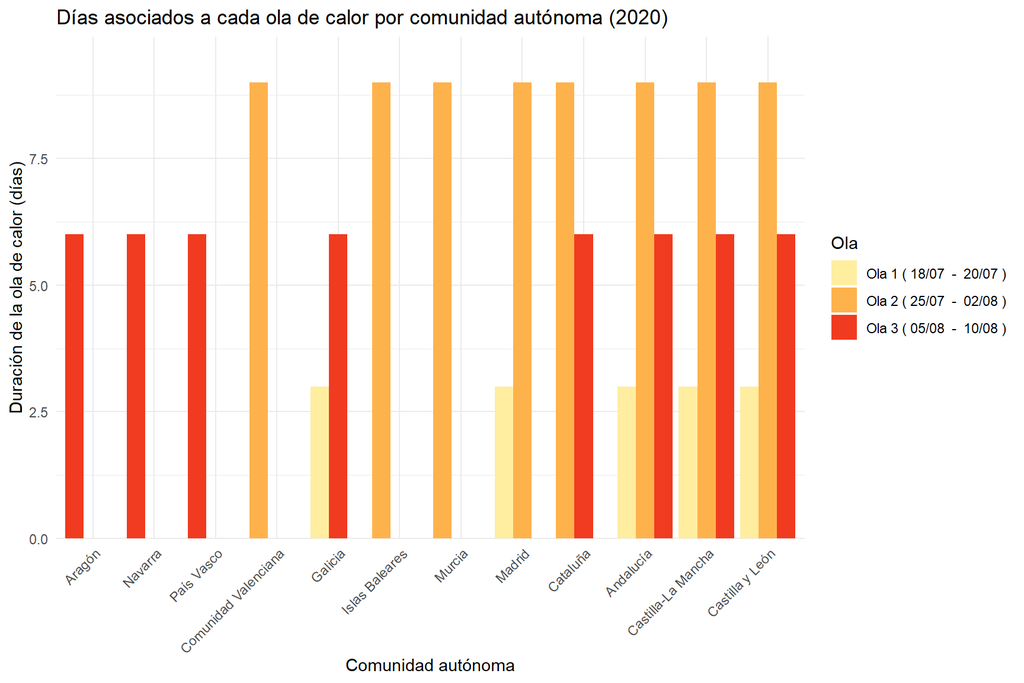

```r
olas_ccaa_ola <- olas %>%
  left_join(prov_ccaa, by = "provincia") %>%
  distinct(ccaa, id_ola, fecha_inicio, fecha_fin, duracion_dias) %>%
  mutate(ola = paste("Ola", id_ola, "(",
                      format(fecha_inicio, "%d/%m"), " - ",
                      format(fecha_fin, "%d/%m"), ")"))

G1 <- ggplot(data = olas_ccaa_ola,
             mapping = aes(x = reorder(ccaa, duracion_dias, sum),
                           y = duracion_dias, fill = ola)) +
  geom_col(position = position_dodge(preserve = "single")) +
  scale_fill_brewer(palette = "YlOrRd") +
  scale_y_continuous(expand = expansion(mult = c(0, 0.1))) +
  labs(x = "Comunidad autónoma",
       y = "Duración de la ola de calor (días)",
    fill = "Ola",
    title = paste( "Días asociados a cada ola de calor por comunidad autónoma (2020)")) +
  theme_minimal() +
  theme(axis.text.x = element_text(angle = 45, hjust = 1))

G1
```

En 2020 se registraron 3 olas de calor nacionales, que afectaron de manera diferente a las comunidades autónomas.

- Castilla y León, Castilla-La Mancha y Andalucía sufrieron las 3 olas de calor, lo que suma aproximadamente unos 18 días de calor intenso.
- Cataluña estuvo entre las olas 2 y 3 (15 días).
- Madrid sufrió las olas 2 y 1 (12 días).
- Galicia, las olas 3 y 1
- Murcia, Baleares y la Comunidad Valenciana solo estuvieron en la ola 2 (9 días) y País Vasco, Navarra y Aragón solo en la ola 3 (6 días).

En este gráfico una comunidad suma los días de una ola si al menos una de sus provincias fue afectada por la ola. Las comunidades autónomas que no aparecen no sufrieron ninguna ola.

### Gráfico 2: número de olas por provincia

De las 52 provincias analizadas, 34 estuvieron incluidas en al menos una de las olas de calor nacionales registradas por AEMET.

En este otro gráfico también utilizamos un diagrama de barras horizontales en el que representamos en el eje x en número de olas de calor y en el eje y las distintas provincias.

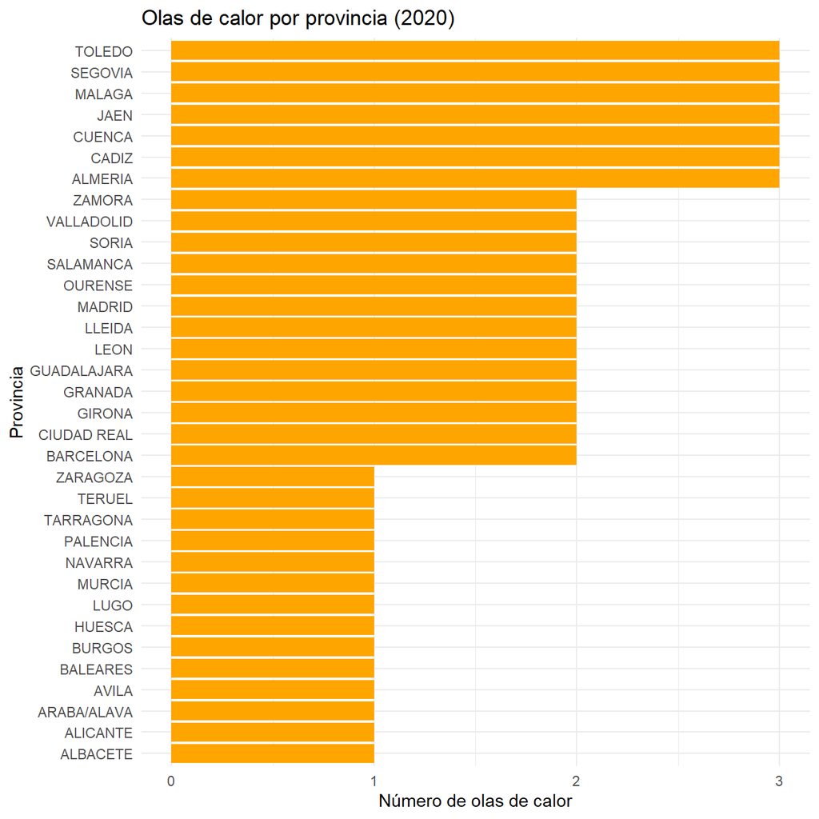

```r
G2 <- olas_prov %>%
  filter(n_olas > 0) %>%
  ggplot(mapping = aes(
    x = reorder(provincia, n_olas),
    y = n_olas)) +
  geom_col(fill = "orange") +
  coord_flip() +
  scale_y_continuous(breaks = 0:3) +
  labs(
    x = "Provincia",
    y = "Número de olas de calor",
    title = "Olas de calor por provincia (2020)") +
  theme_minimal()

G2
```

Según el número de olas de calor de 2020 (hubo tres) en las que figura cada provincia:

- **Las 3 olas:** Toledo, Segovia, Málaga, Jaén, Cuenca, Cádiz y Almería.
- **2 olas:** Zamora, Valladolid, Soria, Salamanca, Ourense, Madrid, Lleida, León, Guadalajara, Granada, Girona, Ciudad Real y Barcelona.
- **1 ola:** Zaragoza, Teruel, Tarragona, Palencia, Navarra, Murcia, Lugo, Huesca, Burgos, Baleares, Ávila, Álava, Alicante y Albacete.

El resto de provincias no aparecen en el gráfico porque no figuran en ninguna de las tres olas. Este gráfico cuenta en cuántas olas está cada provincia, pero no mide la intensidad del calor, una provincia incluida en una ola a lo mejor no tuvo ola de calor todos los días del intervalo.

### Mapa de la península sobre las olas de calor

```r
#Código extraido de Olas_calor.
# Obtenemos las geometrías de las provincias españolas.Canarias se desplaza para obtener un mapa más compacto.

mapa_provincias <- mapSpain::esp_get_prov(
  moveCAN = TRUE,
  epsg = 4326
)

# Convertimos los nombres de provincia de olas_prov a códigos provinciales oficiales del INE.

olas_prov_mapa <- olas_prov %>%
  mutate(
    cpro = mapSpain::esp_dict_region_code(
      provincia,
      origin = "text",
      destination = "cpro"
    )
  ) %>%
  select(
    cpro,
    n_olas,
    dias_ola
  )

# Comprobamos si alguna provincia no ha sido reconocida.El resultado esperado es una tabla con cero filas.

olas_prov_mapa %>%
  filter(
    is.na(cpro)
  )
```

| cpro | n_olas | dias_ola |
| --- | --- | --- |

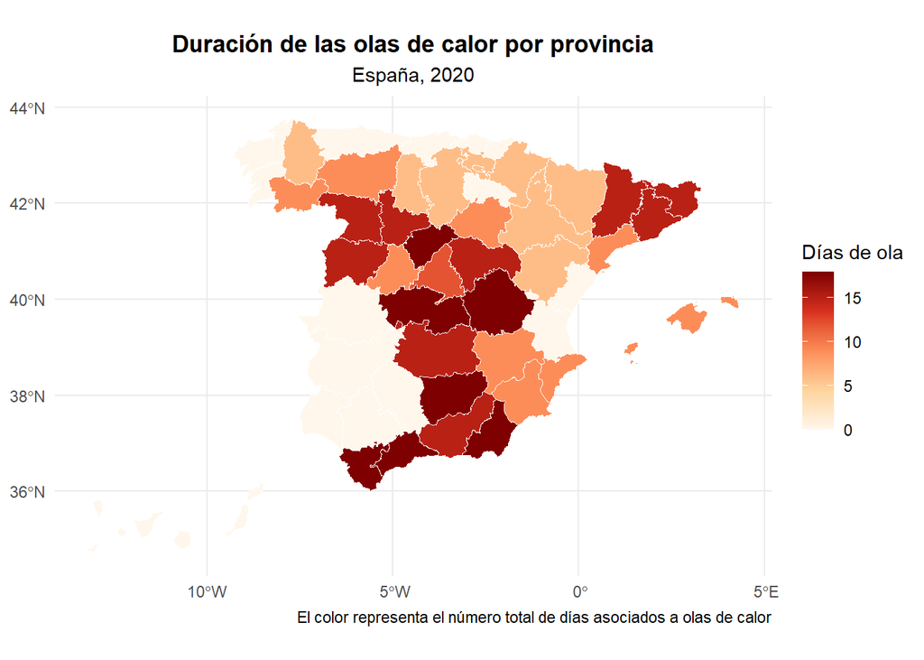

```r
# Unimos los datos de las olas con las geometrías.

mapa_olas <- mapa_provincias %>%
  left_join(
    olas_prov_mapa,
    by = "cpro"
  ) %>%
  mutate(
    n_olas = replace_na(n_olas, 0),
    dias_ola = replace_na(dias_ola, 0),

    informacion = paste0(
      "<b>Provincia: ", ine.prov.name, "</b>",
      "<br>Días de ola: ", dias_ola,
      "<br>Número de olas: ", n_olas
    )
  )

# Creamos el mapa base con ggplot2.

G8 <- ggplot(
  data = mapa_olas
) +
  geom_sf(
    mapping = aes(
      fill = dias_ola,
      text = informacion
    ),
    color = "white",
    linewidth = 0.3
  ) +
  scale_fill_gradientn(
    colours = c(
      "#FFF7EC",
      "#FDD49E",
      "#FC8D59",
      "#D7301F",
      "#7F0000"
    ),
    name = "Días de ola"
  ) +
  labs(
    title = "Duración de las olas de calor por provincia",
    subtitle = "España, 2020",
    caption = paste(
      "El color representa el número total de días",
      "asociados a olas de calor"
    )
  ) +
  theme_minimal() +
  theme(
    legend.position = "right",

    plot.title = element_text(
      hjust = 0.5,
      face = "bold"
    ),

    plot.subtitle = element_text(
      hjust = 0.5
    )
  )

G8
```

```r
# Convertimos el mapa de ggplot2 en un elemento interactivo.
# En el HTML se podrá ampliar, desplazar y consultar la información de cada provincia.

mapa_interactivo_olas <- plotly::ggplotly(
  G8,
  tooltip = "text"
) %>%
  plotly::config(
    scrollZoom = TRUE,
    displayModeBar = TRUE,
    responsive = TRUE
  )

mapa_interactivo_olas
```

[interactive chart not shown]

Para poder estudiar de manera más visual el impacto de las olas de calor en cada provincia, hemos realizado este mapa. El color indica los días de ola de calor en 2020 en los que figura cada provincia, sumando los de las tres olas. Comprobamos que la exposición de las olas de calor en 2020 fue desigual en el territorio. Algunas provincias tuvieron hasta 18 días de ola (entre las 3 olas) mientras otras no tuvieron ni uno. La exposición también varía dentro de la misma ccaa: en Andalucía, las provincias de Sevilla y Huelva no tuvieron ninguna ola mientras que en provincias como Almería, Jaén y Málaga sufrieron las 3 olas. En Castilla y León ocurre lo mismo, en Segovia hubo 18 días de ola, sin embargo en Burgos hubo solo 6.

En los siguientes gráficos estudiamos las defunciones en cada comunidad autónoma teniendo en cuenta el COVID-19.

## Pregunta 2: ¿En qué comunidades aumentaron más las defunciones en 2020 respecto a 2019?

A la hora de responder esta pregunta y las que tienen relación con las defunciones y las comunidades autónomas, utilizaremos las siguientes variables teniendo en cuenta la población de cada ccaa (tasas por 100.000 habitantes).

```r
datos_tasas
```

| ccaa | var_defunciones | muertes_covid | n_provincias | prov_afectadas_ola | n_olas_media | dias_ola_media | poblacion | diferencia_muertes_NoCovd | defunciones_no_covid_100000 | var_defuncion_100k | covid_100k | resto_100k | pct_covid |
| --- | --- | --- | --- | --- | --- | --- | --- | --- | --- | --- | --- | --- | --- |
| País Vasco | 2806 | 2781 | 3 | 1 | 0.3333333 | 2.00000 | 2220504 | 25 | 1.125871 | 126.4 | 125.2 | 1.1 | 99.1 |
| Murcia | 984 | 746 | 1 | 1 | 1.0000000 | 9.00000 | 1511251 | 238 | 15.748542 | 65.1 | 49.4 | 15.7 | 75.8 |
| Navarra | 1267 | 1002 | 1 | 1 | 1.0000000 | 6.00000 | 661197 | 265 | 40.078827 | 191.6 | 151.5 | 40.1 | 79.1 |
| Comunidad Valenciana | 5762 | 3138 | 3 | 1 | 0.3333333 | 3.00000 | 5057353 | 2624 | 51.884850 | 113.9 | 62.0 | 51.9 | 54.5 |
| La Rioja | 633 | 571 | 1 | 0 | 0.0000000 | 0.00000 | 319914 | 62 | 19.380208 | 197.9 | 178.5 | 19.4 | 90.2 |
| Ceuta | 114 | 59 | 1 | 0 | 0.0000000 | 0.00000 | 84202 | 55 | 65.319114 | 135.4 | 70.1 | 65.3 | 51.8 |
| Melilla | 97 | 47 | 1 | 0 | 0.0000000 | 0.00000 | 87076 | 50 | 57.421103 | 111.4 | 54.0 | 57.4 | 48.5 |
| Madrid | 19584 | 14659 | 1 | 1 | 2.0000000 | 12.00000 | 6779888 | 4925 | 72.641318 | 288.9 | 216.2 | 72.6 | 74.9 |
| Galicia | 1929 | 1512 | 4 | 2 | 0.7500000 | 3.75000 | 2701819 | 417 | 15.434046 | 71.4 | 56.0 | 15.4 | 78.4 |
| Extremadura | 1784 | 1143 | 2 | 0 | 0.0000000 | 0.00000 | 1063987 | 641 | 60.245097 | 167.7 | 107.4 | 60.2 | 64.1 |

[output cut: 9 more lines]

Para responder esta pregunta realizamos los siguientes gráficos:

### Gráfico 3: Aumento de defunciones por ccaa en 2020 respecto 2019

Utilizamos un gráfico de puntos ordenado, en el eje x representamos el aumento de defunciones por cada 100.000 hab en 2020 respecto 2019 y en el eje y las comunidades autónomas

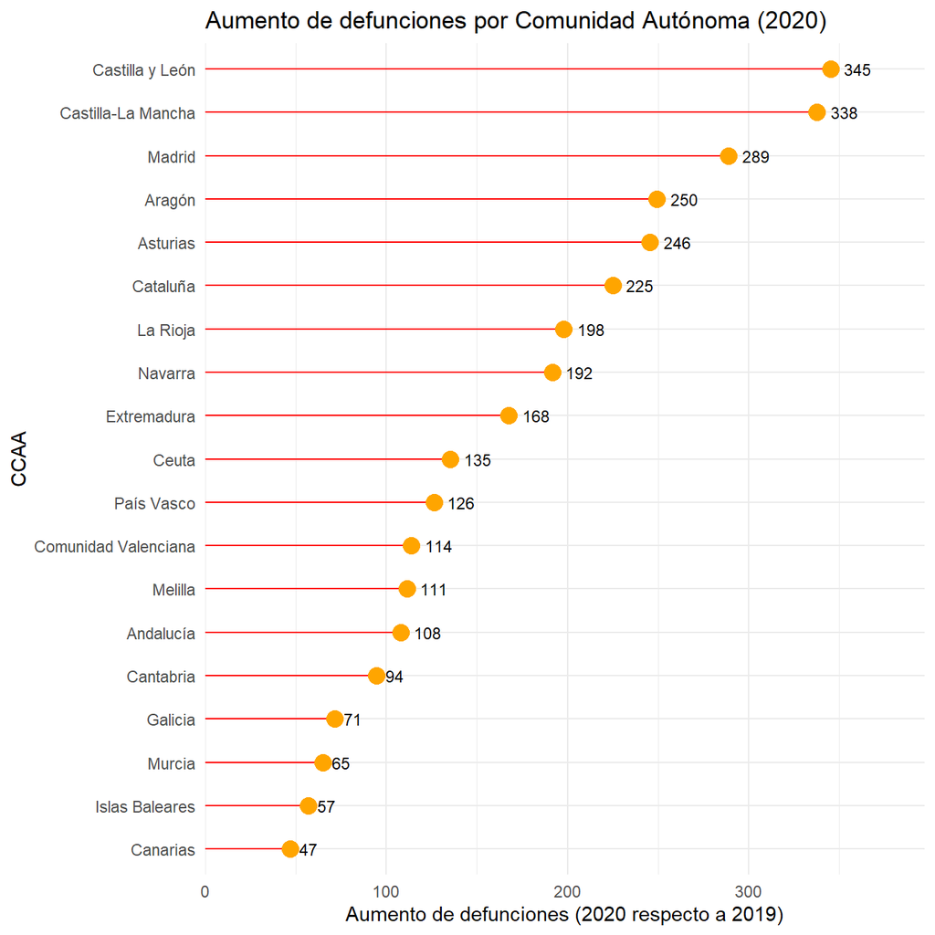

```r
G3 <- datos_tasas %>%
  mutate(ccaa = reorder(ccaa, var_defuncion_100k)) %>%
  ggplot(mapping = aes(x = ccaa, y = var_defuncion_100k)) +
  geom_segment(mapping = aes(xend = ccaa, yend = 0),
               colour = "red") +
  geom_point(size = 4, colour = "orange") +
  geom_text(mapping = aes(label = round(var_defuncion_100k)),
            hjust = -0.5, size = 3) +
  coord_flip() +
  scale_y_continuous(expand = expansion(mult = c(0, .15))) +
  labs(x = "CCAA",
       y = "Aumento de defunciones (2020 respecto a 2019)",
       title = "Aumento de defunciones por Comunidad Autónoma (2020)") +
  theme_minimal()

G3
```

Al ajustar por población, el aumento de muertes en 2020 respecto a 2019 varía considerablemente entre las 19 comunidades y ciudades autónomas analizadas.

La comunidad con menor aumento fue **Canarias**, con aproximadamente **47.1 defunciones adicionales por cada 100.000 habitantes**. En el extremo contrario, la comunidad con mayor aumento fue **Castilla y León**, con aproximadamente **345.3 defunciones adicionales por cada 100.000 habitantes**.

El ajuste por población modifica el orden respecto a las cifras absolutas. Algunas comunidades con muchas defunciones, como Madrid, Cataluña o Andalucía, tienen también poblaciones más numerosas. Por esta razón, las tasas por cada 100.000 habitantes permiten realizar una comparación más adecuada entre territorios.

Este gráfico recoge el aumento total de defunciones, incluidas las atribuidas oficialmente al COVID-19. En la siguiente pregunta analizamos qué parte de ese aumento corresponde al COVID-19.

## Pregunta 3: ¿Qué parte del aumento de defunciones corresponde a muertes por COVID-19?

En el conjunto de comunidades analizadas, las defunciones atribuidas oficialmente al COVID-19 representan aproximadamente el **71 %** del aumento de defunciones observado en 2020 respecto a 2019.

Para estudiar las diferencias territoriales, separamos en cada comunidad las muertes atribuidas al COVID-19 y el exceso de mortalidad restante.

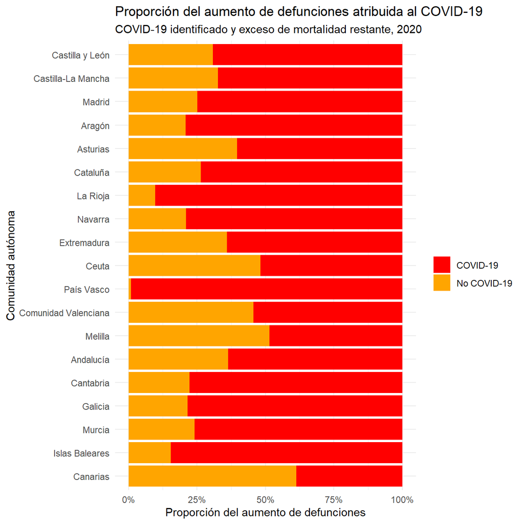

```r
muertes_causa <- bind_rows(
  datos_tasas %>% transmute(ccaa, causa = "COVID-19",
                             defunciones = covid_100k),
  datos_tasas %>% transmute(ccaa, causa = "No COVID-19",
                             defunciones = resto_100k)
)

G4 <- muertes_causa %>%
  ggplot(aes(x = reorder(ccaa, defunciones, sum),
             y = defunciones, fill = causa)) +
  geom_col(position = "fill") +
  coord_flip() +
  scale_fill_manual(values = c("COVID-19" = "red",
                               "No COVID-19" = "orange")) +
  scale_y_continuous(labels = scales::label_percent(accuracy = 1)) +
  labs(x = "Comunidad autónoma",
       y = "Proporción del aumento de defunciones",
       fill = "",
       title = "Proporción del aumento de defunciones atribuida al COVID-19",
       subtitle = "COVID-19 identificado y exceso de mortalidad restante, 2020") +
  theme_minimal()

G4
```

Obviamente, la mayoría del aumento de defunciones de 2020 con respecto 2019 se debe a los casos de muerte por COVID-19, ya que esta pandemia se llevo una gran cantidad de vidas por todo el mundo. Lo que realmente nos interesa es a que se debe el aumento de muertes de la parte naranja, es decir, No Covid. En Canarias y Melilla hay más aumento de muertes por No Covid que por Covid. ¿Estará relacionado con las olas de calor?

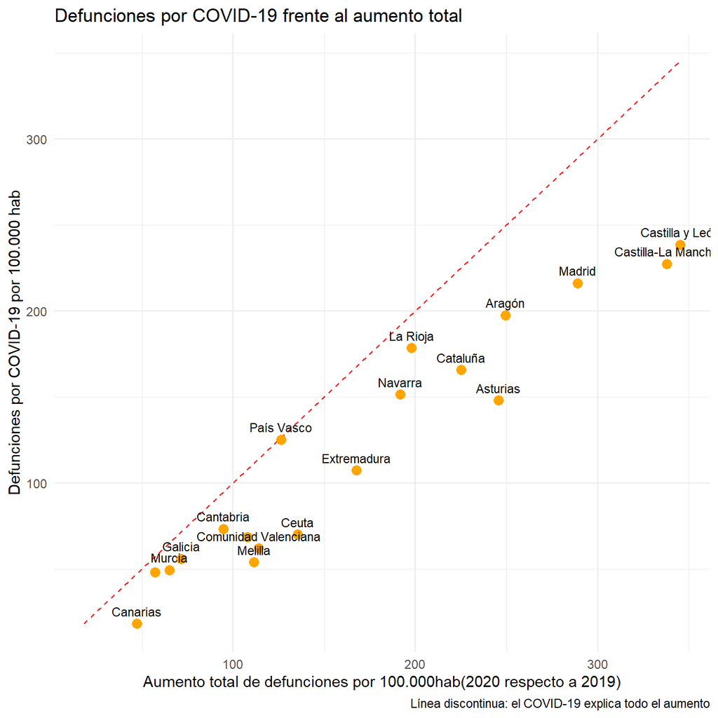

```r
#Gráfico 6:relación entre defunciones por covid y aumento total
limites <- range(c(datos_tasas$var_defuncion_100k,
                   datos_tasas$covid_100k), na.rm = TRUE)

linea_referencia <- data.frame(
  x_inicio = limites[1],
  y_inicio = limites[1],
  x_fin = limites[2],
  y_fin = limites[2]
)

G6 <- datos_tasas %>%
  ggplot(mapping = aes(x = var_defuncion_100k,
                       y = covid_100k)) +
  geom_segment(data = linea_referencia,
               mapping = aes(x = x_inicio, y = y_inicio,
                             xend = x_fin, yend = y_fin),
               inherit.aes = FALSE,
               linetype = "dashed",
               colour = "red") +
  geom_point(size = 3, colour = "orange") +
  geom_text(mapping = aes(label = ccaa),
            vjust = -0.8, size = 3,
            check_overlap = TRUE) +
  labs(x = "Aumento total de defunciones por 100.000hab(2020 respecto a 2019)",
       y = "Defunciones por COVID-19 por 100.000 hab",
       title = "Defunciones por COVID-19 frente al aumento total",
       caption = "Línea discontinua: el COVID-19 explica todo el aumento") +
  theme_minimal()

G6
```

La línea roja discontinua representa cómo sería si el COVID - 19 explicara el 100% de aumento de las muertes. Como podemos observar todas las comunidades autónomas estan por debajo de esta línea, salvo País Vasco que está justo encima de dicha línea.

## Pregunta 4: ¿Tiene relación ese aumento de muertes con las olas de calor?

Para resolver esta pregunta,utilizamos los datos de defunciones por semanas. Al usar estos datos en lugar de los globales de defunciones podemos comprobar si justo en la fecha de las olas de calor, o semanas posteriores hubo más muertes (excluyendo las de COVID) o si por el contrario no, y nuestra hipótesis no se sostiene.

Calculamos cuantos días de ola hubo en cada ccaa en cada semana

```r
olas_ccaa_fechas <- olas %>%
  left_join(prov_ccaa, by = "provincia") %>%
  distinct(ccaa, id_ola, fecha_inicio, fecha_fin) #eliminamos las filas repetidas

semanas <- tabla_semanal %>%
  distinct(semana, fecha_2020) %>%
  mutate(sem_inicio = fecha_2020 - 3, sem_fin = fecha_2020 + 3) #en los datos, la fecha de la semana viene indicada por jueves. Restamos 3 días para conseguir el lunes y sumamos 3 para llegar hasta el domingo

dias_ola_semana <- crossing(olas_ccaa_fechas, semanas) %>% #combinamos cada ola de calor registrada en cada comunidad con cada una de las semanas del año.
  mutate(dias =
           pmax(0, as.numeric(pmin(fecha_fin, sem_fin) -
                                pmax(fecha_inicio, sem_inicio)) + 1)) %>%
  group_by(ccaa, semana) %>%
  summarise(dias_ola = sum(dias), .groups = "drop")

dias_ola_semana
```

| ccaa | semana | dias_ola |
| --- | --- | --- |
| Andalucía | 1 | 0 |
| Andalucía | 2 | 0 |
| Andalucía | 3 | 0 |
| Andalucía | 4 | 0 |
| Andalucía | 5 | 0 |
| Andalucía | 6 | 0 |
| Andalucía | 7 | 0 |
| Andalucía | 8 | 0 |
| Andalucía | 9 | 0 |
| Andalucía | 10 | 0 |

[output cut: 614 more lines]

```r
exceso_no_covid <- tabla_semanal %>%
  left_join(covid_semanal, by = c("ccaa", "semana")) %>%
  left_join(dias_ola_semana, by = c("ccaa", "semana")) %>%
  left_join(poblacion_2020, by = "ccaa") %>%
  mutate(dias_ola = replace_na(dias_ola, 0),     # comunidades sin ninguna ola

         variacion_no_covid = variacion_def_semanal - muertes_covid,
         variacion_no_covid_100k = round(variacion_no_covid / poblacion * 1e5))

exceso_no_covid
```

| ccaa | semana | fecha_2019 | fecha_2020 | muertes_2019 | muertes_2020 | variacion_def_semanal | muertes_covid | dias_ola | poblacion | variacion_no_covid | variacion_no_covid_100k |
| --- | --- | --- | --- | --- | --- | --- | --- | --- | --- | --- | --- |
| Andalucía | 52 | 2019-12-26 | 2020-12-24 | 1503 | 1557 | 54 | 151 | 0 | 8464411 | -97 | -1 |
| Andalucía | 51 | 2019-12-19 | 2020-12-17 | 1451 | 1604 | 153 | 154 | 0 | 8464411 | -1 | 0 |
| Andalucía | 50 | 2019-12-12 | 2020-12-10 | 1421 | 1578 | 157 | 193 | 0 | 8464411 | -36 | 0 |
| Andalucía | 49 | 2019-12-05 | 2020-12-03 | 1342 | 1703 | 361 | 290 | 0 | 8464411 | 71 | 1 |
| Andalucía | 48 | 2019-11-28 | 2020-11-26 | 1411 | 1691 | 280 | 400 | 0 | 8464411 | -120 | -1 |
| Andalucía | 47 | 2019-11-21 | 2020-11-19 | 1440 | 1797 | 357 | 481 | 0 | 8464411 | -124 | -1 |
| Andalucía | 46 | 2019-11-14 | 2020-11-12 | 1328 | 1913 | 585 | 532 | 0 | 8464411 | 53 | 1 |
| Andalucía | 45 | 2019-11-07 | 2020-11-05 | 1305 | 1899 | 594 | 509 | 0 | 8464411 | 85 | 1 |
| Andalucía | 44 | 2019-10-31 | 2020-10-29 | 1349 | 1764 | 415 | 411 | 0 | 8464411 | 4 | 0 |
| Andalucía | 43 | 2019-10-24 | 2020-10-22 | 1266 | 1708 | 442 | 320 | 0 | 8464411 | 122 | 1 |

[output cut: 978 more lines]

Con los nuevos datos de defunciones por semanas comprobamos si existe alguna relación entre el aumento de muertes en las fechas de ola de calor con las mismas.

### Gráfico 7: Olas de calor y defunciones (sin COVID)

Como primera aproximación comparamos, para cada comunidad, la media de días de ola de calor por provincia con la variación de defunciones no COVID-19 por 100.000 habitantes en 2020 respecto a 2019. Cada punto es una comunidad autónoma y la recta azul es un ajuste lineal con su intervalo de confianza.

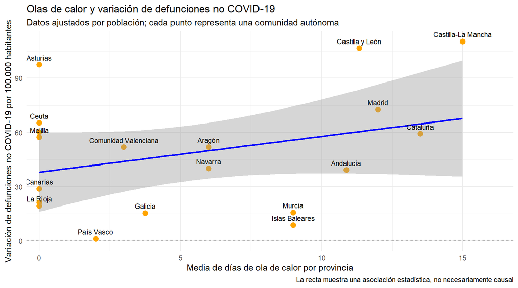

```r
datos_g7 <- datos_unidos %>%
  mutate(
    defunciones_no_covid_100000 =
      diferencia_muertes_NoCovd / poblacion * 100000
  ) %>%
  filter(
    !is.na(dias_ola_media),
    !is.na(defunciones_no_covid_100000)
  )

G7 <- ggplot(datos_g7, aes(x = dias_ola_media,
                           y = defunciones_no_covid_100000 )) +
  geom_hline(yintercept = 0, linetype = "dashed", colour = "grey60") +
  geom_point(colour = "orange", size = 3 ) +
  geom_smooth( method = "lm", se = TRUE, colour = "blue" ) +
  geom_text(aes(label = ccaa), vjust = -0.8, size = 3, check_overlap = TRUE) +
  scale_x_continuous(expand = expansion(mult = c(0.03, 0.12))) +
  labs(
    title = "Olas de calor y variación de defunciones no COVID-19",
    subtitle = "Datos ajustados por población; cada punto representa una comunidad autónoma",
    x = "Media de días de ola de calor por provincia",
    y = "Variación de defunciones no COVID-19 por 100.000 habitantes",
    caption = "La recta muestra una asociación estadística, no necesariamente causal"
  ) +
  theme_minimal()

G7
```

La recta tiene pendiente positiva: las comunidades con más días de ola de calor, como Castilla-La Mancha, Madrid, Cataluña y Castilla y León, tienden a presentar un mayor exceso de mortalidad no atribuido oficialmente al COVID-19. Sin embargo, la relación es débil y el intervalo de confianza es muy amplio, por lo que con estos datos no podemos asegurar que exista una asociación clara.

Además, hay comunidades sin ninguna ola con valores altos (Asturias, Ceuta, Extremadura, Melilla) y comunidades con muchos días de ola y valores bajos (Murcia, Islas Baleares). Por tanto, la relacion general anual no tiene sentido porque está llena de contradicciones. Tenemos sitios donde hubo muchas muertes sin apenas hacer calor, y sitios donde hizo un mucho calor pero apenas hubo muertes extra.

Otra posible explicación es que las comunidades con más días de ola son también de las más afectadas por la primera ola de COVID-19 en primavera, y parte de las muertes que aquí figuran como “no COVID” pueden ser COVID-19 no identificado en esos meses.

Por todos estos motivos, los datos anuales mezclan demasiados efectos y no nos permiten llegar a una conclusión válida. Para aislar el efecto real de las temperaturas analizamos únicamente los datos semanales centrados en los meses de verano.

### Gráfico 10:variación de defunciones por CCAA según la inclusión en las olas nacionales

Dividimos las comunidades en dos grupos: las que figuran en alguna ola de calor de 2020 y las que no (Asturias, Cantabria, Canarias, Extremadura, La Rioja, Ceuta y Melilla). Para cada grupo calculamos, semana a semana, la variación de defunciones respecto a la misma semana de 2019, restando las muertes por COVID-19, por cada 100.000 habitantes. Nos centramos en las semanas 22 a 38 (finales de mayo a septiembre), periodo en el que tienen lugar las olas de calor y cuando la incidencia del COVID-19 era menor y es menos probable que el exceso “no COVID” sea en realidad COVID-19 sin identificar. La línea gris marca el 0 (misma mortalidad que en 2019) y las franjas naranjas indican las fechas de las tres olas de calor nacionales, las cuales solo afectan a las comunidades del grupo “con ola”.

```r
exposicion <- exceso_no_covid %>%
  group_by(ccaa) %>%
  summarise(dias_ola_total = sum(dias_ola), .groups = "drop") %>%
  mutate(grupo = ifelse(dias_ola_total > 0,"Incluidas en alguna ola nacional","No incluidas en las olas nacionales"))

lineas <- exceso_no_covid %>%
  left_join(exposicion, by = "ccaa") %>%
  group_by(grupo, semana, fecha_2020) %>%
  summarise(tasa = sum(variacion_no_covid) / sum(poblacion) * 1e5, .groups = "drop") %>%
  filter(semana >= 22, semana <= 38) #filtramos por las semanas en las que hay alguna ola de calor
lineas
```

| grupo | semana | fecha_2020 | tasa |
| --- | --- | --- | --- |
| Incluidas en alguna ola nacional | 22 | 2020-05-28 | -0.63155933 |
| Incluidas en alguna ola nacional | 23 | 2020-06-04 | -1.21800728 |
| Incluidas en alguna ola nacional | 24 | 2020-06-11 | -0.67429643 |
| Incluidas en alguna ola nacional | 25 | 2020-06-18 | -1.23700154 |
| Incluidas en alguna ola nacional | 26 | 2020-06-25 | -0.36326533 |
| Incluidas en alguna ola nacional | 27 | 2020-07-02 | -0.88798191 |
| Incluidas en alguna ola nacional | 28 | 2020-07-09 | 0.49147662 |
| Incluidas en alguna ola nacional | 29 | 2020-07-16 | 0.23030547 |
| Incluidas en alguna ola nacional | 30 | 2020-07-23 | 0.41312527 |
| Incluidas en alguna ola nacional | 31 | 2020-07-30 | 2.85151411 |

[output cut: 24 more lines]

```r
olas_fechas <- olas %>%
  distinct(id_ola, fecha_inicio, fecha_fin)
olas_fechas
```

| id_ola | fecha_inicio | fecha_fin |
| --- | --- | --- |
| 1 | 2020-07-18 | 2020-07-20 |
| 2 | 2020-07-25 | 2020-08-02 |
| 3 | 2020-08-05 | 2020-08-10 |

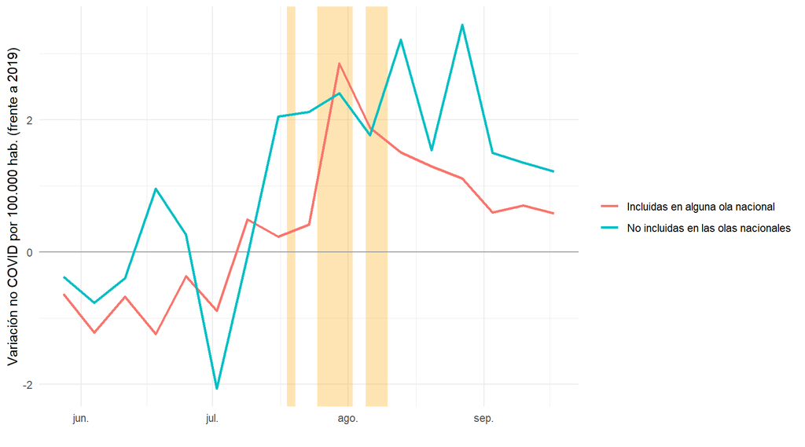

```r
G10<- ggplot(lineas, aes(x = fecha_2020, y = tasa, colour = grupo)) +
  geom_rect(data = olas_fechas,
            aes(xmin = fecha_inicio, xmax = fecha_fin, ymin = -Inf, ymax = Inf),
            inherit.aes = FALSE,  #utilizamos FALSE ya que vamos a crear una capa independiente encima
            fill = "orange", alpha = 0.3) +
  geom_hline(yintercept = 0, colour = "grey60") +
  geom_line(linewidth = 1) +
  labs(x = "", y = "Variación no COVID por 100.000 hab. (frente a 2019)", colour = "") +
  theme_minimal()

G10
```

Ambos grupos parten de valores negativos en junio (es decir, registraron menos muertes “no COVID” que en 2019). Si nos fijamos en las comunidades con ola (línea roja), la subida más destacada es el pico de la semana del 30 de julio, coincidiendo con la segunda ola de calor (del 25 de julio al 2 de agosto). En ese punto la variación alcanza un máximo de 2,85 defunciones extra por cada 100.000 habitantes. Sin embargo, la primera ola (18-20 de julio) apenas muestra un cambio apreciable, y para cuando llega la tercera (5-10 de agosto), la curva de mortalidad de este grupo ya se encontraba en descenso.

Por otro lado, las comunidades no incluidas en las olas nacionales (línea azul) presentan varios picos. Tras una caída a principios de julio, sus valores aumentan y se mantienen por encima del otro grupo durante buena parte de agosto y septiembre. Esto muestra que el aumento de mortalidad del verano no fue exclusivo de las regiones incluidas por AEMET en las tres olas nacionales. Además, este grupo tiene una población mucho menor, por lo que sus tasas semanales presentan mayor variabilidad.

### Gráfico 9: variaciones de defunción en los meses de verano

Repetimos el mismo análisis pero esta vez separado por comunidades, ordenadas de más a menos días de olas de calor. Cada franja naranja corresponde a las olas que afectaron específicamente a esa comunidad. Como cada panel tiene su propia escala vertial no debemos comparar el tanaño de los picos entre gráficas, sino fijarnos en si el momento en el que sube la mortalidad coincide temporalmente con las franjas naranjas de las olas.

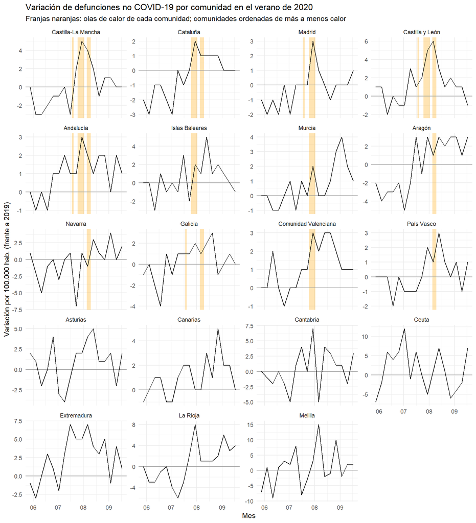

```r
ventanas <- exceso_no_covid %>%
  filter(semana >= 22, semana <= 38) %>%
  left_join(olas_ccaa %>% select(ccaa, dias_ola_media), by = "ccaa") %>%
  mutate(ccaa = fct_reorder(ccaa, -dias_ola_media))      #de más a menos calor

olas_ventanas <- olas %>%
  left_join(prov_ccaa, by = "provincia") %>%
  distinct(ccaa, id_ola, fecha_inicio, fecha_fin) %>%
  mutate(ccaa = factor(ccaa, levels = levels(ventanas$ccaa))) #los niveles van a a ser las ccaa de cada ventana

G9 <- ggplot(ventanas, aes(x = fecha_2020, y = variacion_no_covid_100k)) +
  geom_rect(data = olas_ventanas,
            aes(xmin = fecha_inicio, xmax = fecha_fin, ymin = -Inf, ymax = Inf),
            inherit.aes = FALSE, fill = "orange", alpha = 0.3) +
  geom_hline(yintercept = 0, colour = "grey60") +
  geom_line() +
  facet_wrap(vars(ccaa), ncol = 4, scales = "free_y") +
  scale_x_date(date_breaks = "1 month", date_labels = "%m") +
  labs(title = "Variación de defunciones no COVID-19 por comunidad en el verano de 2020",
       subtitle = "Franjas naranjas: olas de calor de cada comunidad; comunidades ordenadas de más a menos calor",
       x = "Mes", y = "Variación por 100.000 hab. (frente a 2019)") +
  theme_minimal()
G9
```

En las cuatro comunidades con más días de ola (Castilla-La Mancha, Cataluña, Madrid y Castilla y León), vemos un patrón claro: la variación pasa de valores cercanos a 0 o negativos en junio a un pico máximo (de entre 2 y 6 defunciones extra por 100.000 habitantes) que coincide de con las franjas de la segunda y tercera ola. En Andalucía, Galicia, la Comunidad Valenciana y el País Vasco también se aprecia un repunte claro coincidiendo con las franjas de calor.

Sin embargo, la gráfica también nos muestra claras excepciones que rompen esta regla. En Murcia y Navarra, el pico máximo de muertes llega bastante después de que termine la ola. En Aragón, el aumento de mortalidad empieza mucho antes de su única franja de calor y se mantiene alto durante todo el verano. Además, si miramos la mitad inferior del panel, las comunidades sin ola (Asturias, Canarias, Cantabria, Extremadura, La Rioja, Ceuta y Melilla) también sufren picos de mortalidad fortísimos. Por ejemplo, Extremadura se dispara por encima de 5 desde mediados de julio a pesar de no registrar olas.

Hay que tener en cuenta que en las regiones con menos población (como Ceuta, Melilla, La Rioja o Cantabria), las series son mucho más irregulares y “puntiagudas”, ya que muy pocas defunciones reales alteran muchísimo la tasa por 100.000 habitantes.

### Conclusión de la pregunta 4

El problema es que ese mismo repunte de muertes también nos sale en comunidades donde AEMET no registró participación en las tres olas nacionales. Además, aquí entra en juego el factor de la pandemia: es muy posible que parte de ese exceso de muertes ‘no COVID’ sean en realidad casos de COVID-19 que no se diagnosticaron.

En resumen, no podemos afirmar rotundamente que las olas de calor expliquen todo este exceso de mortalidad. Es una posibilidad real, pero al mezclarse con los efectos de la pandemia y darse aumentos también en zonas sin calor, con los datos que tenemos ni lo podemos confirmar al 100% ni lo podemos descartar.

## Conclusiones generales

**Qué hemos encontrado.**

En 2020 hubo tres olas de calor en España. Las comunidades más afectadas fueron Castilla y León, Castilla-La Mancha y Andalucía, que aparecen en las tres olas y suman unos 18 días de calor intenso. En cambio, Asturias, Cantabria, Canarias, Extremadura, La Rioja, Ceuta y Melilla no aparecen en ninguna.

Ese mismo año murió más gente que en 2019 en todas las comunidades. El aumento fue muy distinto según el sitio: desde 47 defunciones más por cada 100.000 habitantes en Canarias hasta 345 más en Castilla y León. La mayor parte de ese aumento se debe al COVID-19, como era de esperar.

**Qué relación hay con las olas de calor.**

Primero miramos el año entero. Vimos que las comunidades con más días de ola tienden a tener más muertes “no COVID”, pero la relación es muy débil y poco fiable. Hay comunidades sin olas con muchas muertes extra y comunidades con muchas olas con pocas muertes. Además, el año entero mezcla la primera ola de COVID-19 de la primavera, y parte de esas muertes “no COVID” pueden ser casos de COVID-19 que no se diagnosticaron.

Por eso pasamos a mirar semana a semana solo en verano, cuando había pocos casos de COVID-19. En Castilla-La Mancha, Madrid, Cataluña y Castilla y León, las muertes extra suben justo cuando llega la segunda ola de calor (del 25 de julio al 2 de agosto), que fue la más larga y la que afectó a más provincias. En Andalucía, Galicia, la Comunidad Valenciana y el País Vasco también se ve un pequeño repunte en esas fechas. En cambio, la primera ola, que solo duró tres días, apenas cambia nada.

Pero hay cosas que no encajan. En Murcia y Navarra el pico llega bastante después de la ola. En Aragón las muertes extra empiezan a subir antes de su ola y se mantienen altas todo el verano. También hay subidas de muertes en comunidades donde no hubo ninguna ola, como Extremadura.

**Limitaciones.**

- Los datos de AEMET dicen qué provincias entraron en cada ola, pero no qué días exactos estuvo cada una. Por eso los días de ola son una aproximación.
- Solo comparamos con 2019.
- Las muertes “no COVID” salen de restar dos fuentes distintas. Pueden incluir COVID-19 sin diagnosticar, sobre todo en primavera, y otros efectos de la pandemia.
- Solo tenemos 19 comunidades y tres olas, que son pocos datos. En las comunidades pequeñas (Ceuta, Melilla, La Rioja, Cantabria) unas pocas muertes cambian mucho las cifras.
- No tenemos la edad de la población ni la temperatura de cada día, y trabajamos por comunidades, así que no podemos hablar de causas a nivel individual.